# Sparklyr workshop - R Users Galicia

A. Baluja

16 julio, 2019

# What is sparklyr?

- Exposes Spark’s API (in Scala) from R.
- Spark lets us access to the Hadoop ecocystem.
- To put it simple, dplyr over Spark!.
- Created by Rstudio in 2016.

[How does Spark work?](https://aurora-mareviv.github.io/sparklyr_test/#/como-funciona-spark-2)

# Notebook setup

#### Clone this repo

```
$ git clone https://github.com/aurora-mareviv/sparklyr_start
```

```r
R_version_current <- paste0(version$major, ".", version$minor)
R_version_tutorial <- "3.5.1"
if (R_version_current < R_version_tutorial) message("Your R version is not updated; please go to: https://cran.r-project.org")
```

```
## Your R version is not updated; please go to: https://cran.r-project.org
```

```r
# Installs missing libraries on render!
list.of.packages <- c("sparklyr", "rmarkdown", "dplyr", "Rcpp", "knitr", "ggplot2")
new.packages <- list.of.packages[!(list.of.packages %in% installed.packages()[,"Package"])]
if(length(new.packages)) install.packages(new.packages, repos='https://cran.rstudio.com/')
```

```r
library(dplyr)
library(ggplot2)
library(sparklyr)
options(scipen=999)
```

```r
source("./assets/rscripts/test.R", echo=FALSE) # if you want to source some R script
```

```r
# directory where the notebook is
wdir <- getwd()
# directory where data are imported from & saved to
datadir <- file.path(wdir, "data") # better than datadir <- paste(wdir, "/data", sep="")
# directory where external images are imported from
imgdir <- file.path(wdir, "img")
# directory where plots are saved to
outdir <- file.path(wdir, "out")
# the folder immediately above root dir
Up <- paste("\\", basename(wdir), sep="")
wdirUp <- gsub(Up, "", wdir)
```

# Spark setup

From within RStudio, we can easily install Spark:

```r
spark_install()
```

# Loading spark context (RDDs)

Currently there are three types of contexts:

- Local context:
  - Interactive.
  - If the user exits session, the tasks are terminated (use screen to run after session close).
  - All processes reside in the LOGIN node (both drivers and executors).
  - Can only be used for tasks that require very few resources.
- YARN-client:
  - Interactive.
  - If the user exits session, the tasks are terminated (use screen to run after session close).
  - The driver resides in the LOGIN node, but the executors are in the CLUSTER nodes. Thus, executors can use all the memory available for the task in the CLUSTER nodes.
  - Can be used for memory-intensive tasks.
- YARN-cluster:
  - Not interactive.
  - Both the driver and the executors reside in the CLUSTER nodes.
  - Can be used for memory-intensive tasks.
  - Currenty doesn’t seem available for this version of R/sparklyr.
  - Defining a new context (sc) overwrites the previous one.

We’ll set some session variables

```r
SPARK_HOME = Sys.getenv("SPARK_HOME") # but the path to Spark may be different in some cases!
# SPARK_HOME = ""
# SPARK_HOME = "~/spark/spark-2.3.1-bin-hadoop2.7" # MacOS
# SPARK_HOME = "/usr/lib/spark" # GNUL
```

Create a Spark context:

```r
#sc <- spark_connect(master = "local")
sc <- spark_connect(master = "local", spark_home = SPARK_HOME)
```

The connection `sc` will let us interact with Spark. The general pipeline we’ll use will be:

- Upload the data to the HDFS HOME (in case there is one). For comparison, it works as if it was another disk partition we must transfer our files to.
- Add the data set to the Spark context `sc`. In this tutorial the master node will be local. This means that all the processes will reside in our local machine. Our PC will be both **driver** and **cluster**.
- Once data is added, we will read it into `sparklyr`.
- Make vectorised transformations over our dataframe (“map” operations).
- Make our “reduce” operations.
- Collect the results back into our driver. This will let us make tables and graphs.

## Upload data to HDFS

In case we are dealing with an HDFS cluster, we must first upload our data to our HDFS HOME

In local mode, this is not necessary, as we are not leaving our PC.

## Reading JSON into Spark context: `jscars.json`

```r
jscars <- spark_read_json(sc, name = "jscars", path = file.path(datadir, "jscars.json") )
```

```r
jscars %>%
  head(6) %>%
  collect()
   # A tibble: 6 x 11
        am  carb   cyl  disp  drat  gear    hp   mpg  qsec    vs    wt
     <dbl> <dbl> <dbl> <dbl> <dbl> <dbl> <dbl> <dbl> <dbl> <dbl> <dbl>
   1     1     4     6   160  3.9      4   110  21    16.5     0  2.62
   2     1     4     6   160  3.9      4   110  21    17.0     0  2.88
   3     1     1     4   108  3.85     4    93  22.8  18.6     1  2.32
   4     0     1     6   258  3.08     3   110  21.4  19.4     1  3.22
   5     0     2     8   360  3.15     3   175  18.7  17.0     0  3.44
   6     0     1     6   225  2.76     3   105  18.1  20.2     1  3.46
```

## Basic data wrangling

We can make good use of `magrittr::%>%` *pipes* for data wrangling or window operations:  
The `warnings` issued here are usually not important. They depend on the `sparklyr` version. See [here](https://github.com/rstudio/sparklyr/issues/426) for more info.

```r
jscars %>%
  group_by(vs) %>%
  filter(gear == 3, hp > 100) %>%
  mutate(horsepower_by_gear = rank(desc(hp / gear))) %>%
  mutate(mpg_rank = rank(mpg)) %>%
  select(gear, mpg_rank, horsepower_by_gear) %>%
  head(6) %>%
  collect()
   # A tibble: 6 x 4
        vs  gear mpg_rank horsepower_by_gear
     <dbl> <dbl>    <int>              <int>
   1     0     3        1                  4
   2     0     3        1                  5
   3     0     3        3                  1
   4     0     3        4                  1
   5     0     3        5                  3
   6     0     3        6                  6
```

## Graphs

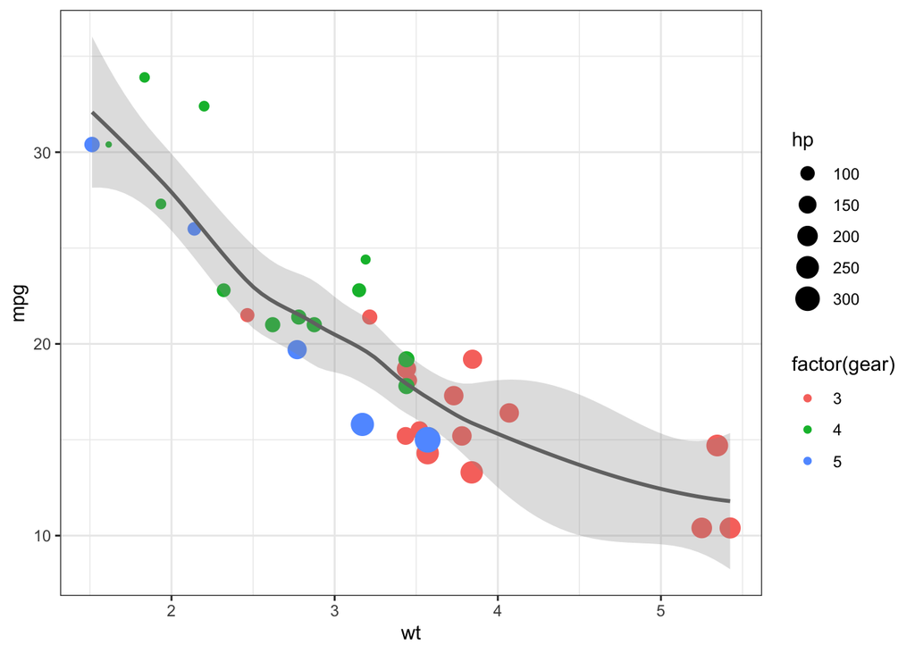

```r
jscars %>%
  collect() %>%
    ggplot(aes(wt, mpg)) +
    geom_point(aes(colour=factor(gear), size=hp)) +
    geom_smooth(colour="#737373", alpha=0.3) +
    theme_bw()
```

# Models: K-means

```r
kmeans_model <- jscars %>%
  select(wt, mpg) %>%
  ml_kmeans(y ~ wt + mpg, k = 3)

print(kmeans_model)
   K-means clustering with 3 clusters

   Cluster centers:
           wt      mpg
   1 1.873000 30.06667
   2 4.058667 14.45833
   3 3.072143 20.64286

   Within Set Sum of Squared Errors =  154.0229
# kmeans_model %>% str()
```

```r
# predict the associated class
predicts <- sdf_predict(jscars, kmeans_model)
predicted <- collect(predicts)
collect(head(predicted))
   # A tibble: 6 x 13
        am  carb   cyl  disp  drat  gear    hp   mpg  qsec    vs    wt
     <dbl> <dbl> <dbl> <dbl> <dbl> <dbl> <dbl> <dbl> <dbl> <dbl> <dbl>
   1     1     4     6   160  3.9      4   110  21    16.5     0  2.62
   2     1     4     6   160  3.9      4   110  21    17.0     0  2.88
   3     1     1     4   108  3.85     4    93  22.8  18.6     1  2.32
   4     0     1     6   258  3.08     3   110  21.4  19.4     1  3.22
   5     0     2     8   360  3.15     3   175  18.7  17.0     0  3.44
   6     0     1     6   225  2.76     3   105  18.1  20.2     1  3.46
   # … with 2 more variables: features <list>, prediction <int>
base::table(predicted$am, predicted$prediction)

        0  1  2
     0  0 10  9
     1  6  2  5
```

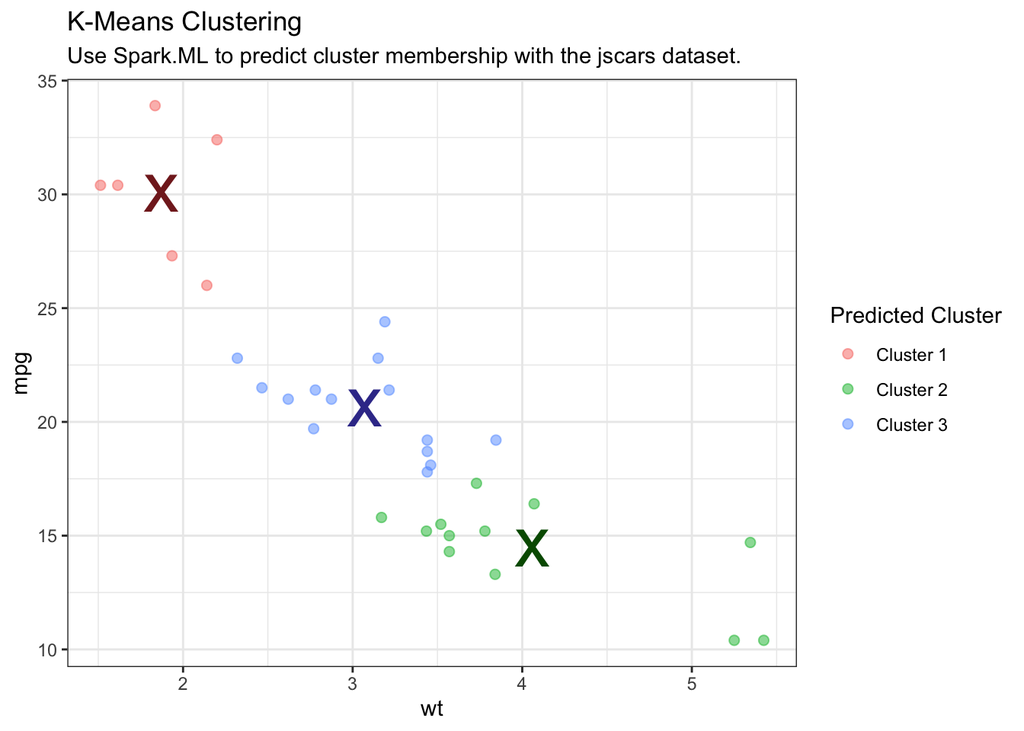

```r
# plot cluster membership
  sdf_predict(jscars, kmeans_model) %>%
  collect() %>%
  ggplot(aes(wt, mpg)) +
    geom_point(aes(wt, mpg, col = factor(prediction + 1)),
               size = 2, alpha = 0.5) +
    geom_point(data = kmeans_model$centers, aes(wt, mpg),
               col = scales::muted(c("red", "green", "blue")),
               pch = 'x', size = 12) +
    scale_color_discrete(name = "Predicted Cluster",
                         labels = paste("Cluster", 1:3)) +
    labs(
      x = "wt",
      y = "mpg",
      title = "K-Means Clustering",
      subtitle = "Use Spark.ML to predict cluster membership with the jscars dataset."
    ) +
    theme_bw()
```

# Session Info

```r
.libPaths()
Sys.getenv("R_HOME")
```

```r
sessionInfo()
   R version 3.4.3 (2017-11-30)
   Platform: x86_64-apple-darwin15.6.0 (64-bit)
   Running under: OS X El Capitan 10.11.6

   Matrix products: default
   BLAS: /Library/Frameworks/R.framework/Versions/3.4/Resources/lib/libRblas.0.dylib
   LAPACK: /Library/Frameworks/R.framework/Versions/3.4/Resources/lib/libRlapack.dylib

   locale:
   [1] es_ES.UTF-8/es_ES.UTF-8/es_ES.UTF-8/C/es_ES.UTF-8/es_ES.UTF-8

   attached base packages:
   [1] stats     graphics  grDevices utils     datasets  methods   base

   other attached packages:
   [1] sparklyr_1.0.0     ggplot2_3.2.0.9000 dplyr_0.8.0.1

   loaded via a namespace (and not attached):
    [1] Rcpp_1.0.1       dbplyr_1.4.0     pillar_1.4.2     compiler_3.4.3
    [5] r2d3_0.2.3       base64enc_0.1-3  tools_3.4.3      zeallot_0.1.0
    [9] digest_0.6.20    jsonlite_1.6     evaluate_0.14    tibble_2.1.3
   [13] gtable_0.3.0     pkgconfig_2.0.2  rlang_0.4.0      cli_1.1.0
   [17] rstudioapi_0.10  DBI_1.0.0        parallel_3.4.3   yaml_2.2.0
   [21] xfun_0.8         withr_2.1.2      stringr_1.4.0    httr_1.4.0
   [25] knitr_1.23       vctrs_0.2.0      askpass_1.1      rappdirs_0.3.1
   [29] generics_0.0.2   htmlwidgets_1.3  rprojroot_1.3-2  grid_3.4.3
   [33] tidyselect_0.2.5 glue_1.3.1       forge_0.2.0      R6_2.4.0
   [37] fansi_0.4.0      rmarkdown_1.12   purrr_0.3.2      magrittr_1.5
   [41] ellipsis_0.2.0.1 backports_1.1.4  scales_1.0.0     htmltools_0.3.6
   [45] assertthat_0.2.1 colorspace_1.4-1 labeling_0.3     config_0.3
   [49] utf8_1.1.4       stringi_1.4.3    openssl_1.3      lazyeval_0.2.2
   [53] munsell_0.5.0    crayon_1.3.4
```

# References

#### Sparklyr

- [`sparklyr` workshop](https://github.com/aurora-mareviv/sparklyr_start)
- [`sparklyr` presentation by RStudio](https://cdn.oreillystatic.com/en/assets/1/event/193/Sparklyr_%20An%20R%20interface%20for%20Apache%20Spark%20Presentation.pdf)
- [`sparklyr` tutorial](http://spark.rstudio.com/).
- [`sparklyr` cheatsheet](https://www.rstudio.com/resources/cheatsheets/#sparklyr).
- [`sparklyr`: creating extensions](http://spark.rstudio.com/extensions.html).
- [Differences between `sparkr` and `sparklyr`](https://stackoverflow.com/questions/39494484/sparkr-vs-sparklyr).
- [Hive Operators and UDFs](https://cwiki.apache.org/confluence/display/Hive/LanguageManual+UDF).
- [String Functions in Hive](http://www.folkstalk.com/2011/11/string-functions-in-hive.html).
- [POSIX regular expressions](https://www.postgresql.org/docs/9.4/static/functions-matching.html#FUNCTIONS-POSIX-REGEXP).

#### PySpark

- [PySpark course](https://github.com/javicacheiro/pyspark_course)
- [Material for Machine Learning Workshop Galicia 2016](http://nbviewer.jupyter.org/github/javicacheiro/machine_learning_galicia_2016/blob/master/notebooks/sentiment_analysis-amazon_books.ipynb).
- [PySpark Programming Guide](https://spark.apache.org/docs/0.9.0/python-programming-guide.html).
- [PySpark cheatsheet](https://s3.amazonaws.com/assets.datacamp.com/blog_assets/PySpark_SQL_Cheat_Sheet_Python.pdf).

#### Jupyter

- [Jupyter shortcuts](https://www.dataquest.io/blog/jupyter-notebook-tips-tricks-shortcuts/)